# Batman Plot Using ggplot2

Peter von Rohr

10/30/2017

[figure not shown]

Batman plots, such as shown above, have been produced many times before. One earlier version which already used `ggplot2` is given at https://guangchuangyu.github.io/2011/08/the-batman-equation/. This author used the so-called **Batman Equations** given at [HardOCP](http://www.hardocp.com/news/2011/07/29/batman_equation/) to come up with a number of dataframes containing the data to be plotted. The data in the dataframes were used as input for the `ggplot2`-plotting routines.

An alternative approach using the mathematical functions of the Batman equation directly for the plot is shown on [CoCalc](https://cocalc.com/projects/db982efa-e439-4e2d-933b-7c7011c6b21a/files/Public/batman-curve.sagews?session=default). In this post, the same approach as on CoCalc is followed, but the mathematical functions from the Batman equation are defined as R-functions and the plots are drawn using `ggplot2`. More information about `ggplot2` is available at http://ggplot2.org/book/.

## Constructing The Batman Plot

According to the example given on [CoCalc](https://cocalc.com/projects/db982efa-e439-4e2d-933b-7c7011c6b21a/files/Public/batman-curve.sagews?session=default), we first define the functions that will later be used for constructing the plot.

```r
sc <- function(x) sqrt(1-x^2)                                # semicircle
el <- function(x) 3*sc(abs(x)/7)                             # ellipse
nl <- function(x) (-1) * el(x)                               # negative of el
sh <- function(x) 4.2 - .5*abs(x) -2.8*sc(.5*abs(x) -.5)     # shoulders
bf <- function(x) sc(abs(2 - abs(x)) - 1) - x^2/11 + .5*abs(x) -3      # bottom
cr  <- data.frame(x = c(0, .5, .8, 1), y = c(1.7, 1.7, 2.6, .9))   # cowl right
cl  <- data.frame(x = -cr$x, y = cr$y)                             # cowl left
```

So far, we have defined the pieces that eventually will be used to produce the whole plot. Next, we define a function that will accept a function and a range of values and will return a plotting object. The following plot-creator function takes into account that the whole Batman-plot is symmetric with respect to the $y$-coordinate axis.

```r
plot_create <- function(fun, xmin, xmax){
  rp <- ggplot2::stat_function(fun = fun, xlim = c(xmin,xmax))
  lp <- ggplot2::stat_function(fun = fun, xlim = c(-xmax, -xmin))
  result_plot <- list(left_plot = lp, right_plot = rp)
  return(result_plot)
}
```

As the first step, we have to initialize our plot object.

```r
require(ggplot2)
### # initialize ggplot object
plot_result <- ggplot(data.frame(x = c(-7,7), y=c(-3,3)), aes(x,y))
```

Now we are ready to add the wings.

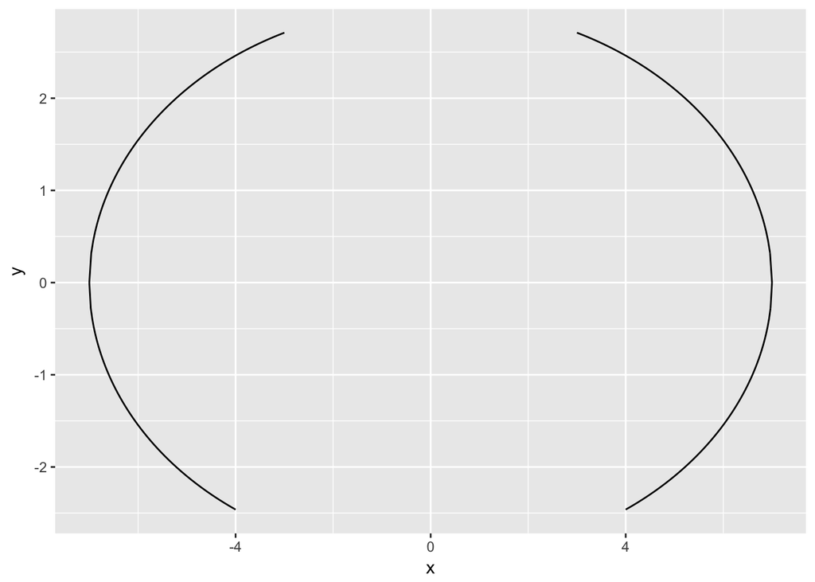

```r
### # get object of plot parts
### # upper part of wing
upper_wing_plot <- plot_create(fun = el, xmin = 3, xmax = 7)
### # lower part of wing
lower_wing_plot <- plot_create(fun = nl, xmin = 4, xmax = 7)
plot_result <- plot_result + upper_wing_plot$left_plot + upper_wing_plot$right_plot +
  lower_wing_plot$left_plot + lower_wing_plot$right_plot
print(plot_result)
```

Next come the shoulders

[figure not shown]

```r
### # shoulder
sh_plot <- plot_create(fun = sh, xmin = 1, xmax = 3)
plot_result <- plot_result + sh_plot$left_plot + sh_plot$right_plot
print(plot_result)
```

Next thing to add is the bottom part.

[figure not shown]

```r
### # bottom
bt_plot <- plot_create(fun = bf, xmin = 0, xmax = 4)
plot_result <- plot_result + bt_plot$left_plot + bt_plot$right_plot
print(plot_result)
```

Finally, what remains to be done is the cowls for which we are usin ordinary lines.

[figure not shown]

```r
plot_result <- plot_result + geom_path(data = cr)
plot_result <- plot_result + geom_path(data = cl)
print(plot_result)
```